# Netflix Movies and TV Shows Analysis

Jaenal Aripin

2024-03-18

## 1. Netflix

[figure not shown]

Netflix is an American subscription video on-demand over-the-top streaming service. The service primarily distributes original and acquired films and television shows from various genres, and it is available internationally in multiple languages.

## 2. Data Source

We’ve just obtained ‘netflix_titles’ dataset from Kaggle, which you can download the data [here](https://www.kaggle.com/datasets/shivamb/netflix-shows/data). The dataset contains 8807 titles, which consists of TV Shows and Movies from around the world.

- How Netflix has grown year over year.
- What types of shows are most added to Netflix.

The dataset does not contain values like movie ratings, user reviews, total watched, total likes or dislikes, and watch later. It makes the analysis limited to movie demography. The dataset itself only contains values like.

- Show type
- Show title
- Director
- Cast
- Country
- Date added
- Release year
- Content rating
- Genre
- Duration
- Description

## 2. Importing Data Set

We use Microsoft SQL Server for this analysis. Before we start importing the dataset, we need to create a new database first. In this analysis, the new database name would be ‘NetflixMovies’.

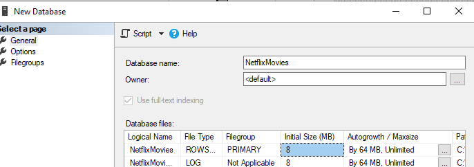

After the new database has been created, we can import the dataset using SQL Server Import and Export Data. We can open this window by right click the database name NetflixMovies and then dropdown menu will show, choose Task > Import Data

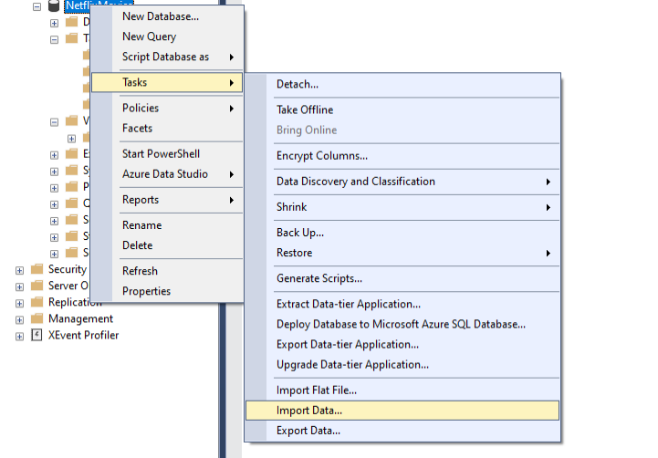

Then, we choose Flat File Source, then browse the dataset, and choose netflix_titles.csv

[figure not shown]

## 3. Cleaning

The imported dataset is not clean. We need to clean it first for further analysis.

### 3.1. Cleaning The date_added Column

#### 3.1.1. Converting from String to Date Data Type

First, we need to cast the column first with this query below.

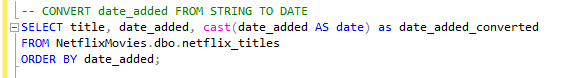

We see that there are some rows in the date_added column that contain empty values. When the empty values are converted into the date data type, it returns the result ‘1900-01-01’. We will fill this empty values with the correct information by observing on the internet, so we will have the complete data in the column.

After did some observations regarding the netflix series or movies added date, we can write the query below to update the table, so the empty values can be filled with the correct information.

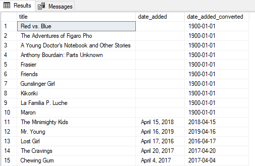

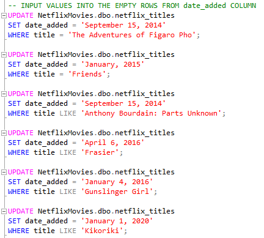

All the empty cells have been filled. Now, we can convert the date_added column data type from string to date using this query.

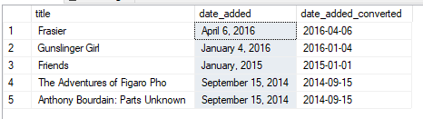

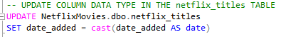

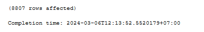

Now, the date_added column is clean. We can move to other colum to perform a similar action.

### 3.2. director Column

#### 3.2.1. Filling Missing Values

The director column also has missing values, based on this query,

[figure not shown]

it returns the 2633 missing values

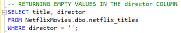

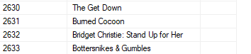

We did some observation on the internet, and fill the missing values in the column with UPDATE clause.

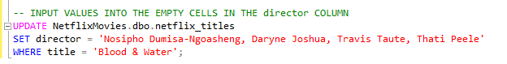

### 3.3. country Column

#### 3.3.1. Filling Missing Values

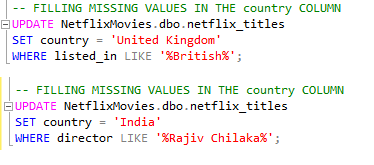

### 3.4. duration Column

duration column has a string data type, but an integer or numeric type for these values is more suitable for further analysis. We want to convert these values from string to numeric data type.

Instead of converting the column, we want to split duration column into two columns, duration_minutes and seasons columns. The duration_minutes column is made for the values that contain ‘min’, and seasons column is made for the values that contain ‘Season’ or ‘Seasons’.

[figure not shown]

### 3.5. rating Column

We found strange values in the rating column, ‘66 min’, ‘74 min’, and ‘84 min’. These values should not be located in the rating column. The duration_minutes column is the correct column to contain these values. So, to make the dataset tidier, we need to move them from the rating to the duration_minutes column. We write this query to move the values.

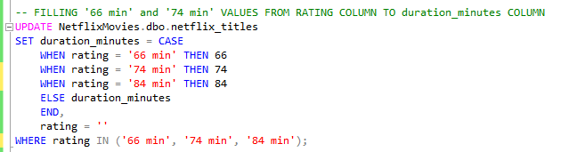

Now, all the misinput values have been moved to the correct column. Unfortunately, there are also some shows that have empty values in the rating column. We need to fill those empty cells with the correct values. We did an observation on the internet about the content rating of those shows. Then, we write this query to fill in the empty cells.

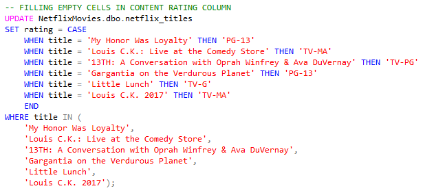

### 3.6. Checking for Duplicates

Now we want to know if the dataset have duplicates, we write this query to return duplicated rows

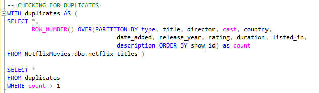

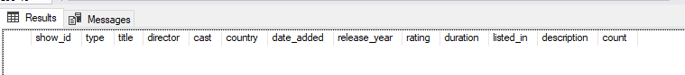

There is no duplicated rows in the dataset. Now, all the values in the data set are clean and ready to be used for further analysis.

## 4. Analysis

Now, we want to analyze the data by performing aggregations to the cleaned dataset.

### 4.1. Counting Shows Per Type

In this analysis, we want to count the numbers of show per type. There are two types of shows in the dataset, Movie and TV Show. We write this query to perform the aggregation.

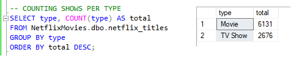

### 4.2. Counting Total Shows Per Genre

There are several genre in the dataset. One show, whether it is movie or TV show, they have several genres listed in. Here, we want to count the numbers of genres and also count the numbers of shows listed in each genre. We write this query to perform this aggregation.

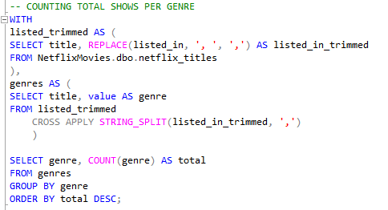

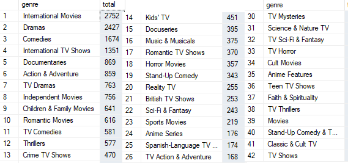

There are 42 different genres based on the query result.

### 4.3. Counting Total Shows Added Per Year

We perform an aggregation to know how many shows added per year, either they are movies or TV shows. We grouped the total shows based on show type and the year added.

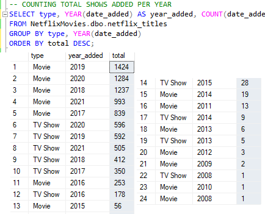

### 4.4. Counting Total Shows Produced by Country

In this analysis, we want to know the numbers of total shows produced by country. We write this query to perform the aggregation.

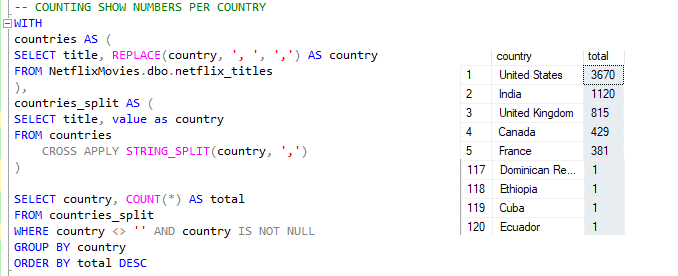

Movies or TV shows that we can watch on Netflix are produced by those 120 countries. The country that produced most of the show was United States, followed by India and UK. Other countries were also contributing, but the numbers as not high as United States and India.

### 4.5. Counting The Numbers of Shows Based on Content Rating

Content ratings classify films based on their suitability for viewing based on age. There are films that are good for children and some that are not. Content ratings are set to prevent viewers from watching films or TV shows that are not age appropriate. Here, we want to know, how many content ratings are available on Netflix. We also want to know the number of shows classified for each content rating.

We write this query to perform the aggregation.

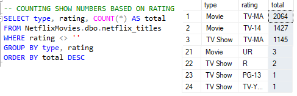

### 4.6. Distribution of Movie Duration

Films generally last between one and three hours. However, some films may only be less than an hour long like short films, or they may be more than three hours long, it depends. We will aggregate the dataset and count the total shows based on their minutes duration. We use the query below to perform the aggregation.

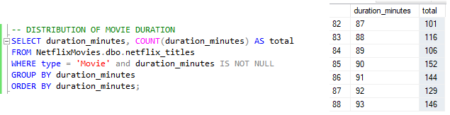

### 4.7. Distribution of TV Serial Seasons

Unlike movies, TV shows generally produced an episode with 40 minutes duration long. TV shows generally have some episodes that are packed in seasons. When the serials are popular, they usually will have another season. The numbers of seasons indicate how popular the series are. We use this query to perform the aggregation.

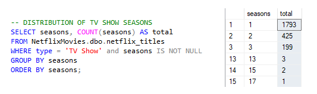

## 5. Visualizations

We made the visualizations in Tableau Public, like the dashboard we can see below.

[figure not shown]

##### SQL code

Here is the [link](https://github.com/jaenalaripin/jaenalaripin.github.io/blob/main/SQL/Netflix_Data_Analysis_06_03_2024_v01.sql) for the complete SQL queries regarding this analysis.